# R notebook de ejemplo

Carlos P. González

Universidad de La Laguna

Carlos G. Alcón

Universidad de La Laguna

11 abril, 2018

Abstract

Este es un ejemplo sencillo de resumen que describe brevemente el propósito de este notebook. A continuación se muestra un ejemplo de algunos aspectos que presenta esta herramienta.

## R notebook

Este es un cuaderno [R Markdown](http://rmarkdown.rstudio.com). Podemos meter elementos interactivos.

De forma similar a los scripts en markdown, al ejecutar el código dentro de este notebook, los resultados aparecen después del código. Por ejemplo, el siguiente trozo (chunk) haciendo click en el botón *Run* dentro del bloque del chunk o colocando el cursor dentro del chunk y presionando *Ctrl+Shift+Enter*.

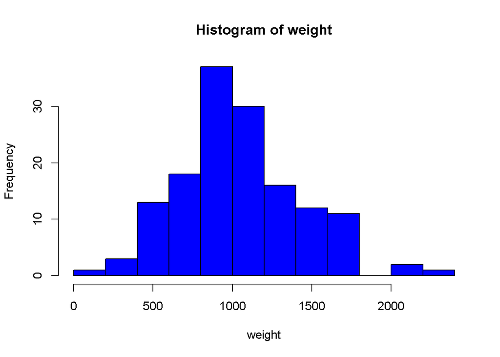

```r
ddt<-read.csv("../ddt.txt",sep="")
hist(ddt$weight,col="blue",main="Histogram of weight",xlab="weight")
```

Para añadir un nuevo chunk hacer click en *Insert* y seleccionar *R* o presionar *Ctrl+Alt+I*.

Cuando se almacena el notebook, se genera un archivo HTML con el código dentro de él y la correspondiente salida de la ejecución (click el botón de *Preview* o presionar *Ctrl+Shift+K* para ver el archivo HTML). Se puede previsualizar tanto en una ventana aparte como integrado dentro del panel *Viewer* del Rstudio.

El preview muestra una copia HTML renderizada de los contenidos del editor. Hay que ejecutar todos los chunks para que la previsualización muestre la salida correctamente.

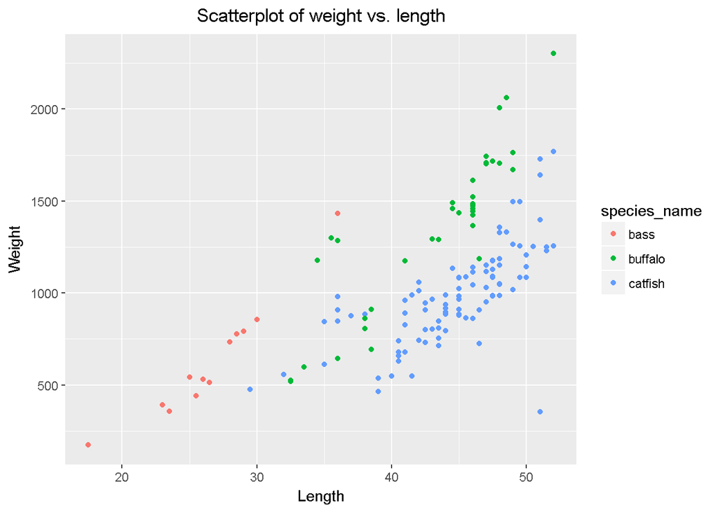

```r
library(ggplot2)
ggplot(ddt,aes(length, weight))+ geom_point(aes(colour=species_name)) +
  xlab("Length") + ylab("Weight") + ggtitle("Scatterplot of weight vs. length") +
  theme(plot.title = element_text(hjust = 0.5))
```

Algunos videos ilustrativos

[video not shown]

[What is R Markdown?](https://vimeo.com/178485416) from [RStudio, Inc.](https://vimeo.com/rstudioinc) on [Vimeo](https://vimeo.com).

[figure not shown]

[Introducing Notebooks with R Markdown – RStudio](https://www.rstudio.com/resources/webinars/introducing-notebooks-with-r-markdown/?wvideo=ics4r8g2j8)

Podemos incluir referencias:

- Utilizar un archivo .bib
- Poner una @ antes de la clave a referenciar, como `@wick1`.
- Wickham (2009) and Wickham (2010) para crear una cita in-text
- (Wickham 2009) para crear una cita entre par?ntesis

# Referencias

Wickham, H. 2009. *Ggplot2: Elegant Graphics for Data Analysis*. Springer-Verlag New York. http://ggplot2.org.

———. 2010. “A Layered Grammar of Graphics.” *Journal of Computational and Graphical Statistics* 19 (1): 3–28.